CHRONOµBIOME / RESEARCH PREVIEW 0.1.0

# Semaglutide exposure: synthetic study

Human microbiome dynamics and responses to exposures

**Synthetic demonstration.** Every participant, abundance, exposure pattern, and result on this page is simulated. These results do not describe the effects of Ozempic or semaglutide in humans.

**32**participants

**320**samples

**12**bacterial features modeled

**8**phage features modeled

## Study design and individual trajectories

Interaction coefficients estimate the difference in baseline-to-phase change between semaglutide and comparator. Causal interpretation requires a suitable design and additional assumptions; it is not supplied by this model.

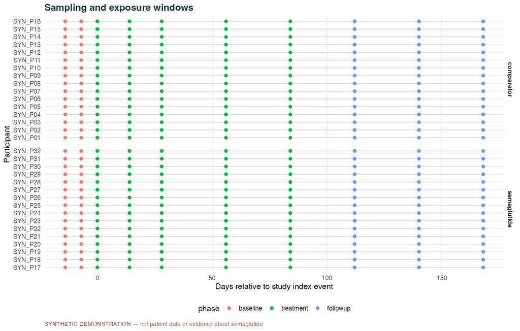

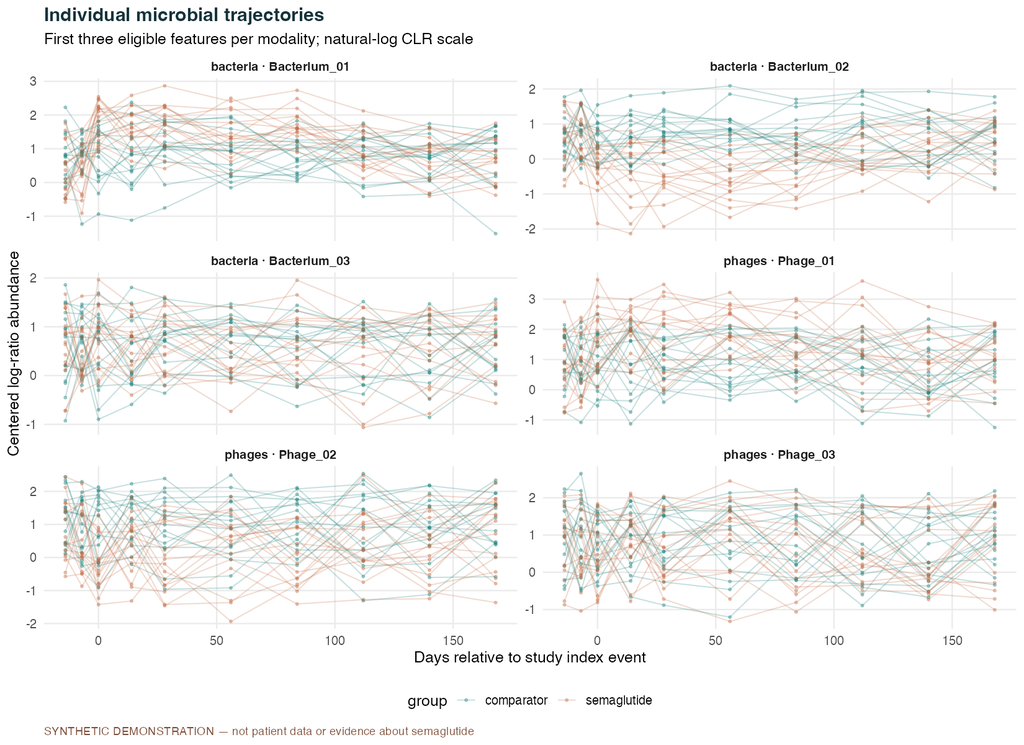

## Exposure-associated changes

Estimates use natural-log centered log-ratio (CLR) abundance. They are relative to the geometric mean of the supplied nonzero features within each modality, not absolute abundance changes or ordinary fold changes.

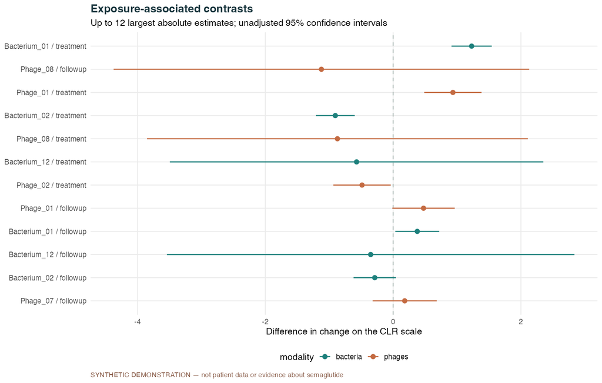

| modality | feature | term | estimate | ci_lower | ci_upper | q_value |
| --- | --- | --- | --- | --- | --- | --- |
| bacteria | Bacterium_01 | groupsemaglutide:phasetreatment | 1.22900 | 0.91370 | 1.54400 | 1.037e-11 |
| bacteria | Bacterium_02 | groupsemaglutide:phasetreatment | -0.90460 | -1.20800 | -0.60080 | 2.539e-07 |
| phages | Phage_01 | groupsemaglutide:phasetreatment | 0.93560 | 0.48790 | 1.38300 | 6.810e-04 |
| bacteria | Bacterium_01 | groupsemaglutide:phasefollowup | 0.37780 | 0.03419 | 0.72140 | 2.700e-01 |
| phages | Phage_02 | groupsemaglutide:phasetreatment | -0.48690 | -0.93600 | -0.03767 | 2.700e-01 |
| phages | Phage_01 | groupsemaglutide:phasefollowup | 0.47580 | -0.01272 | 0.96420 | 3.749e-01 |
| bacteria | Bacterium_02 | groupsemaglutide:phasefollowup | -0.28780 | -0.61930 | 0.04362 | 5.057e-01 |
| bacteria | Bacterium_03 | groupsemaglutide:phasetreatment | 0.15520 | -0.13680 | 0.44720 | 9.748e-01 |
| bacteria | Bacterium_03 | groupsemaglutide:phasefollowup | 0.12400 | -0.19460 | 0.44260 | 9.748e-01 |
| bacteria | Bacterium_04 | groupsemaglutide:phasetreatment | 0.07458 | -0.21760 | 0.36680 | 9.748e-01 |
| bacteria | Bacterium_04 | groupsemaglutide:phasefollowup | 0.14230 | -0.17650 | 0.46110 | 9.748e-01 |
| bacteria | Bacterium_05 | groupsemaglutide:phasetreatment | -0.06436 | -0.36460 | 0.23590 | 9.748e-01 |
| bacteria | Bacterium_05 | groupsemaglutide:phasefollowup | -0.05456 | -0.38220 | 0.27300 | 9.748e-01 |
| bacteria | Bacterium_06 | groupsemaglutide:phasetreatment | -0.04713 | -0.34140 | 0.24710 | 9.748e-01 |
| bacteria | Bacterium_06 | groupsemaglutide:phasefollowup | -0.01014 | -0.33120 | 0.31090 | 9.748e-01 |
| bacteria | Bacterium_07 | groupsemaglutide:phasetreatment | -0.01648 | -0.30030 | 0.26730 | 9.748e-01 |
| bacteria | Bacterium_07 | groupsemaglutide:phasefollowup | -0.02692 | -0.33660 | 0.28270 | 9.748e-01 |
| bacteria | Bacterium_08 | groupsemaglutide:phasetreatment | -0.01224 | -0.29840 | 0.27390 | 9.748e-01 |
| bacteria | Bacterium_09 | groupsemaglutide:phasetreatment | 0.05793 | -0.24290 | 0.35880 | 9.748e-01 |
| bacteria | Bacterium_09 | groupsemaglutide:phasefollowup | 0.01895 | -0.30930 | 0.34720 | 9.748e-01 |

Showing 20 of 40 rows. Complete results are in the TSV downloads.

BH-adjusted p-values cover all planned feature × nonbaseline-phase contrasts across both modalities, separately for each model specification. Confidence intervals are pointwise, not multiplicity-adjusted. Other coefficients are available in the download and are not assigned q-values.

**Sensitivity model: additional conditioning variables**

Added variables: weight_change_pct, fiber_change_g_day. These may be downstream of treatment. This is a sensitivity analysis, not an estimate of a direct or mediated drug effect.

| modality | feature | term | estimate | ci_lower | ci_upper | q_value |
| --- | --- | --- | --- | --- | --- | --- |
| bacteria | Bacterium_01 | groupsemaglutide:phasetreatment | 1.2680000 | 0.89960 | 1.6370 | 2.975e-09 |
| bacteria | Bacterium_01 | groupsemaglutide:phasefollowup | 0.5033000 | 0.05357 | 0.9530 | 2.273e-01 |
| bacteria | Bacterium_02 | groupsemaglutide:phasetreatment | -0.8852000 | -1.24200 | -0.5282 | 3.544e-05 |
| bacteria | Bacterium_02 | groupsemaglutide:phasefollowup | -0.2514000 | -0.68680 | 0.1841 | 7.090e-01 |
| bacteria | Bacterium_03 | groupsemaglutide:phasetreatment | 0.1677000 | -0.17410 | 0.5096 | 7.090e-01 |
| bacteria | Bacterium_03 | groupsemaglutide:phasefollowup | 0.2091000 | -0.20780 | 0.6260 | 7.090e-01 |
| bacteria | Bacterium_04 | groupsemaglutide:phasetreatment | 0.1573000 | -0.18470 | 0.4994 | 7.090e-01 |
| bacteria | Bacterium_04 | groupsemaglutide:phasefollowup | 0.3198000 | -0.09737 | 0.7370 | 6.621e-01 |
| bacteria | Bacterium_05 | groupsemaglutide:phasetreatment | -0.0639200 | -0.41570 | 0.2879 | 8.809e-01 |
| bacteria | Bacterium_05 | groupsemaglutide:phasefollowup | 0.0008473 | -0.42820 | 0.4299 | 9.969e-01 |
| bacteria | Bacterium_06 | groupsemaglutide:phasetreatment | -0.0636700 | -0.40820 | 0.2809 | 8.809e-01 |
| bacteria | Bacterium_06 | groupsemaglutide:phasefollowup | 0.0339200 | -0.38630 | 0.4541 | 9.710e-01 |
| bacteria | Bacterium_07 | groupsemaglutide:phasetreatment | 0.0013090 | -0.33070 | 0.3333 | 9.969e-01 |
| bacteria | Bacterium_07 | groupsemaglutide:phasefollowup | 0.0694000 | -0.33560 | 0.4744 | 8.809e-01 |
| bacteria | Bacterium_08 | groupsemaglutide:phasetreatment | -0.0045170 | -0.33950 | 0.3305 | 9.969e-01 |
| bacteria | Bacterium_08 | groupsemaglutide:phasefollowup | 0.0733200 | -0.33530 | 0.4819 | 8.809e-01 |
| bacteria | Bacterium_09 | groupsemaglutide:phasetreatment | 0.0573200 | -0.29470 | 0.4093 | 8.809e-01 |
| bacteria | Bacterium_09 | groupsemaglutide:phasefollowup | 0.1005000 | -0.32890 | 0.5298 | 8.809e-01 |
| bacteria | Bacterium_10 | groupsemaglutide:phasetreatment | -0.0335100 | -0.36610 | 0.2991 | 9.634e-01 |
| bacteria | Bacterium_10 | groupsemaglutide:phasefollowup | -0.0042110 | -0.40980 | 0.4014 | 9.969e-01 |

Showing 20 of 40 rows. Complete results are in the TSV downloads.

## Persistence and return toward baseline

Community distances use the complete supplied composition, before prevalence filtering. Baseline points use a leave-one-out reference. A descriptive return requires 2 consecutive observed follow-up samples with distance ≤ 0.15. This configurable threshold is not a validated biological recovery criterion. Return is evaluated only after an observed departure during an exposure phase.

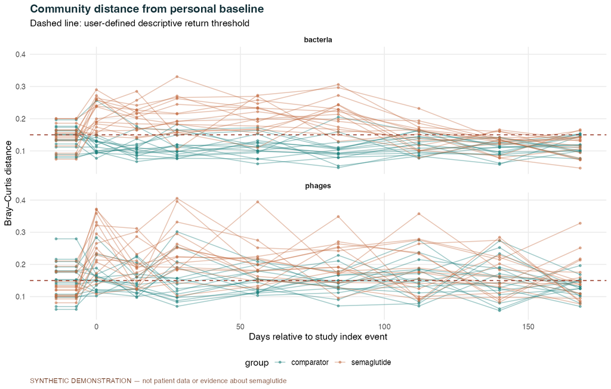

| modality | group | status | participants |
| --- | --- | --- | --- |
| bacteria | comparator | no_observed_departure | 8 |
| phages | comparator | no_observed_departure | 3 |
| bacteria | comparator | not_observed_by_last_sample | 2 |
| phages | comparator | not_observed_by_last_sample | 9 |
| bacteria | semaglutide | not_observed_by_last_sample | 4 |
| phages | semaglutide | not_observed_by_last_sample | 12 |
| bacteria | comparator | observed_return_to_threshold | 6 |
| phages | comparator | observed_return_to_threshold | 4 |
| bacteria | semaglutide | observed_return_to_threshold | 12 |
| phages | semaglutide | observed_return_to_threshold | 4 |

First observed return and confirmation dates are sampling dates, not exact biological recovery times. Missing follow-up is not counted as failure to recover. Feature persistence is the fraction of observed samples above the configured detection threshold; it does not establish continuous colonization.

## Phage–host trajectory associations

3 supplied links meet the primary confidence filter; 2 meet the high-confidence-only filter. Confidence categories are supplied evidence labels, not calibrated probabilities.

| phage_id | host_id | confidence | evidence | status | n_participants | mean_within_person_rho | ci_lower | ci_upper |
| --- | --- | --- | --- | --- | --- | --- | --- | --- |
| Phage_01 | Bacterium_01 | high | Synthetic integration evidence | exploratory | 32 | 0.15190 | 0.04329 | 0.25970 |
| Phage_02 | Bacterium_02 | high | Synthetic CRISPR evidence | exploratory | 32 | 0.01023 | -0.12160 | 0.14810 |
| Phage_03 | Bacterium_03 | medium | Synthetic genus-level prediction | exploratory | 32 | -0.04356 | -0.17110 | 0.06876 |

**High-confidence-only sensitivity**

| phage_id | host_id | confidence | evidence | status | n_participants | mean_within_person_rho | ci_lower | ci_upper |
| --- | --- | --- | --- | --- | --- | --- | --- | --- |
| Phage_01 | Bacterium_01 | high | Synthetic integration evidence | exploratory | 32 | 0.15190 | 0.04329 | 0.2597 |
| Phage_02 | Bacterium_02 | high | Synthetic CRISPR evidence | exploratory | 32 | 0.01023 | -0.12160 | 0.1481 |

These are means of within-participant Spearman correlations of model residuals. Percentile intervals resample participants conditional on fitted models; they do not include model-fitting or host-assignment uncertainty and are not adjusted for multiple comparisons. At least four samples per participant and six eligible participants per pair are required. Correlation does not establish infection, killing, or direction of causation. Lagged inference is not implemented in this release.

## Methods, diagnostics, and provenance

```
response ~ group * phase + age_baseline + bmi_baseline + metformin_baseline
Random intercept: participant_id
Residual correlation: independent
CLR pseudocount (relative-abundance units): 1e-06
Prevalence threshold: 0.1
Detection threshold (relative-abundance units): 0
```

- Exploratory CLR mixed models estimate relative associations, not absolute abundance or causal drug effects.
- Detection depends on sequencing depth; an observed zero is not proof of biological absence.
- Diet, weight change, and gastrointestinal symptoms after exposure may be mediators; covariate selection defines the estimand.
- Sensitivity covariates change the conditioning set; the sensitivity model is not a mediation or direct-effect analysis.
- Residuals are conditionally independent given the random intercept; consider car1 for serial dependence.

**Model fitting status**

| modality | feature | specification | status | message | n_samples | n_participants | residual_sd | random_intercept_sd | car1_rho_per_time_unit |
| --- | --- | --- | --- | --- | --- | --- | --- | --- | --- |
| bacteria | Bacterium_01 | primary | ok |  | 320 | 32 | 0.5408 | 0.3715000 | Not available |
| bacteria | Bacterium_02 | primary | ok |  | 320 | 32 | 0.5217 | 0.4124000 | Not available |
| bacteria | Bacterium_03 | primary | ok |  | 320 | 32 | 0.5015 | 0.4081000 | Not available |
| bacteria | Bacterium_04 | primary | ok |  | 320 | 32 | 0.5019 | 0.3977000 | Not available |
| bacteria | Bacterium_05 | primary | ok |  | 320 | 32 | 0.5157 | 0.3182000 | Not available |
| bacteria | Bacterium_06 | primary | ok |  | 320 | 32 | 0.5053 | 0.3666000 | Not available |
| bacteria | Bacterium_07 | primary | ok |  | 320 | 32 | 0.4874 | 0.3651000 | Not available |
| bacteria | Bacterium_08 | primary | ok |  | 320 | 32 | 0.4915 | 0.4270000 | Not available |
| bacteria | Bacterium_09 | primary | ok |  | 320 | 32 | 0.5167 | 0.3687000 | Not available |
| bacteria | Bacterium_10 | primary | ok |  | 320 | 32 | 0.4863 | 0.4277000 | Not available |
| bacteria | Bacterium_11 | primary | ok |  | 320 | 32 | 0.4983 | 0.5220000 | Not available |
| bacteria | Bacterium_12 | primary | ok | Random intercept variance near boundary | 320 | 32 | 5.0190 | 0.0003358 | Not available |
| bacteria | Bacterium_01 | sensitivity | ok |  | 320 | 32 | 0.5408 | 0.3703000 | Not available |
| bacteria | Bacterium_02 | sensitivity | ok |  | 320 | 32 | 0.5235 | 0.4125000 | Not available |
| bacteria | Bacterium_03 | sensitivity | ok |  | 320 | 32 | 0.5012 | 0.4090000 | Not available |
| bacteria | Bacterium_04 | sensitivity | ok |  | 320 | 32 | 0.5015 | 0.3958000 | Not available |
| bacteria | Bacterium_05 | sensitivity | ok |  | 320 | 32 | 0.5160 | 0.3192000 | Not available |
| bacteria | Bacterium_06 | sensitivity | ok |  | 320 | 32 | 0.5052 | 0.3649000 | Not available |
| bacteria | Bacterium_07 | sensitivity | ok |  | 320 | 32 | 0.4869 | 0.3646000 | Not available |
| bacteria | Bacterium_08 | sensitivity | ok |  | 320 | 32 | 0.4911 | 0.4288000 | Not available |

Showing 20 of 40 rows. Complete results are in the TSV downloads.

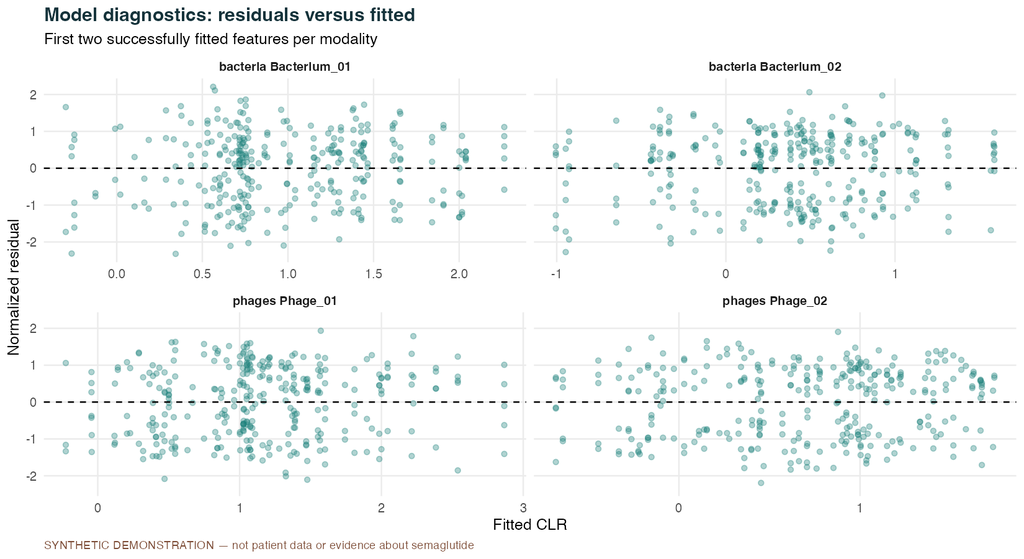

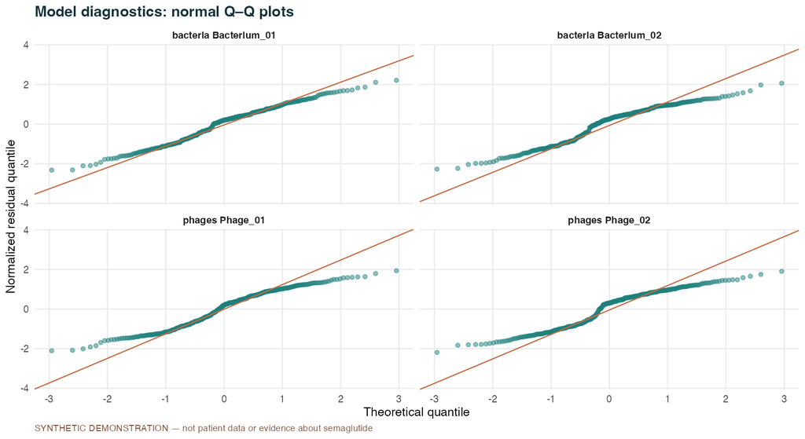

The exploratory CLR model is not a substitute for study-specific differential-abundance validation. Rare taxa, zero replacement, unmeasured confounding, dropout, and serial dependence can affect results. Review diagnostics for every modeled feature using the saved residual table, not just the example plots.

### Complete outputs

- Exposure contrasts
- All model coefficients
- Model status
- Model residuals
- Community distances
- Return-to-baseline status
- Observed persistence
- Host evidence associations
- Feature filtering audit

Run provenance and input checksums · R session information · Resolved configuration

ChronoµBiome (chronomicrobiome) is not affiliated with the existing chronobiome.org research project. This release has synthetic-data checks but has not been externally validated on a real cohort.